# Lecture Notes for Statistics for Biology FS2020

## Drawing random numbers

R also allows us to draw random numbers. This is very handy in many situations. The parameters of rnorm are * the number of observations * the mean of the distirbution * the standard deviation of the distribution

```r
# Let's generate three different vectors of random numbers
# from a normal  distribution
n10 <- rnorm(10, mean = 70, sd = 5)
n100 <- rnorm(100, mean = 70, sd = 5)
n10000 <-  rnorm(10000, mean = 70, sd = 5)

# Let's just look at one of the vectors
n10
```

```
##  [1] 55.05596 63.16401 72.96495 75.74055 59.22078 69.59181 75.80685
##  [8] 81.42968 73.09522 71.84742
```

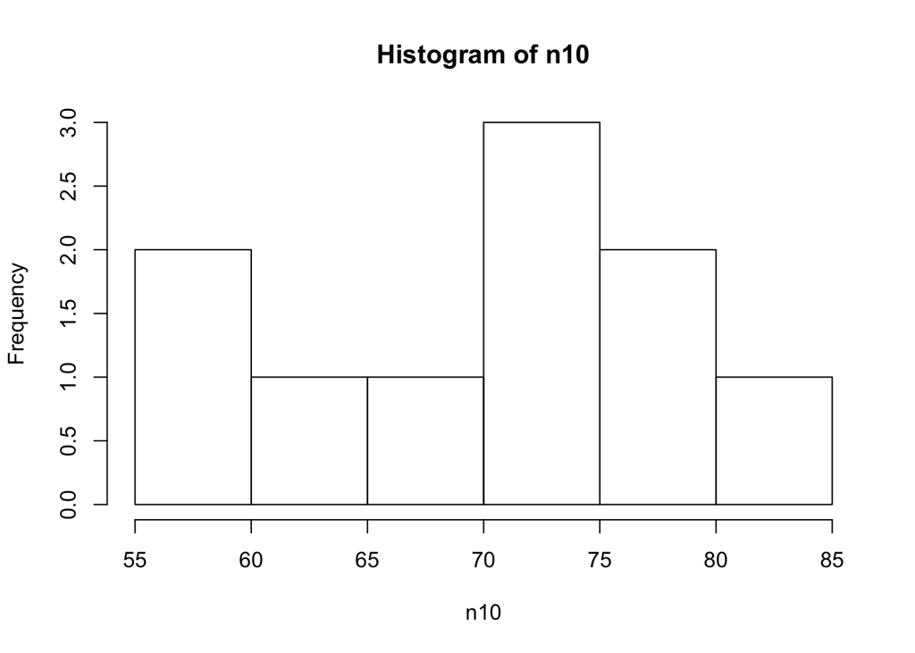

```r
# The breaks argument specifies how many bars are in the histogram
hist(n10, breaks = 5)
```

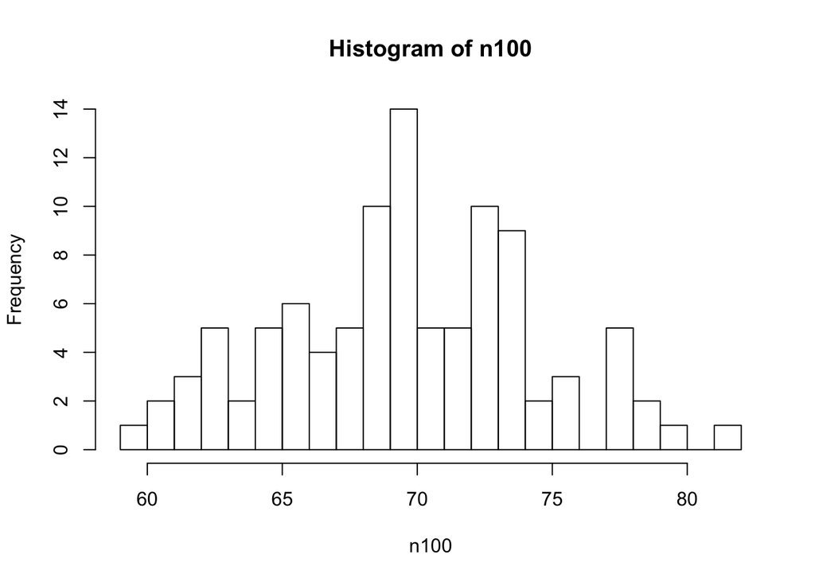

```r
hist(n100, breaks = 20)
```

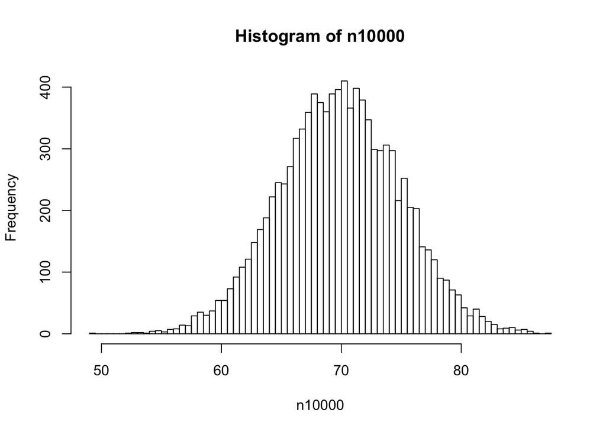

```r
hist(n10000, breaks = 100)
```

*Note:* If we set a *seed* for our random number generator (the algorithm that is used to calcualte a radnom number), we can make our analysis replicable:

```r
set.seed(100)
rnorm(1,0,1)
```

```
## [1] -0.5021924
```

```r
rnorm(1,0,1)
```

```
## [1] 0.1315312
```

```r
set.seed(100)
rnorm(1,0,1)
```

```
## [1] -0.5021924
```

```r
rnorm(1,0,1)
```

```
## [1] 0.1315312
```

## Example: A simple simulation

Copy and paste this R code into a script. Before you run it, try to figure out what it does.

```r
reps = 1000
sample_size = 10
mu = 10
sigma = 5
means = vector("numeric",reps)

for (i in 1:reps)
{
  sample = rnorm(sample_size,mu,sigma)
  means[i] = mean(sample)
}

hist(means,freq=F,main="A distribution")

x = seq(mu-2*sigma,mu+2*sigma,by=0.01)

SE = sigma/sqrt(sample_size)

y = dnorm(x,mu,SE)

lines(x,y)
```

## Plotting Confidence intervalls

We first generate a data frame with a summary of our data (this can be done in many ways, this is a concise one):

```r
CIs <- summarySE(stickleback, measurevar="plates", groupvars=c("genotype"))

CIs
```

```
##   genotype   N   plates        sd        se        ci
## 1       MM  82 62.78049  3.410313 0.3766060 0.7493279
## 2       Mm 174 50.37931 15.146866 1.1482809 2.2664440
## 3       mm  88 11.67045  3.567805 0.3803293 0.7559456
```

and then we use the data frame with our summary to add error bars to our plot:

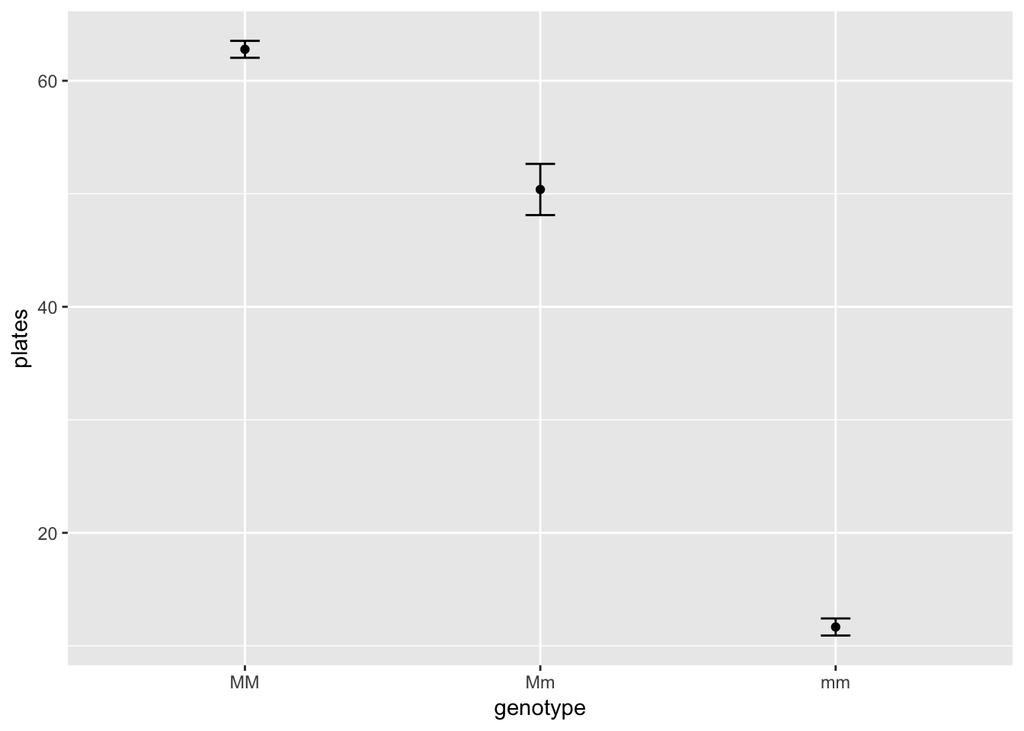

```r
ggplot(data = CIs) +
  geom_point(mapping = aes(x = genotype,y=plates)) +
  geom_errorbar(mapping = aes(x = genotype,y=plates,ymin=plates-ci, ymax=plates+ci), width=.1)
```

*Note:* One can shorten things by specifying the aesthetics in the ggplot command - this simply means that all geom_functions use the same x and y variables (which is very often the case, but not always!):

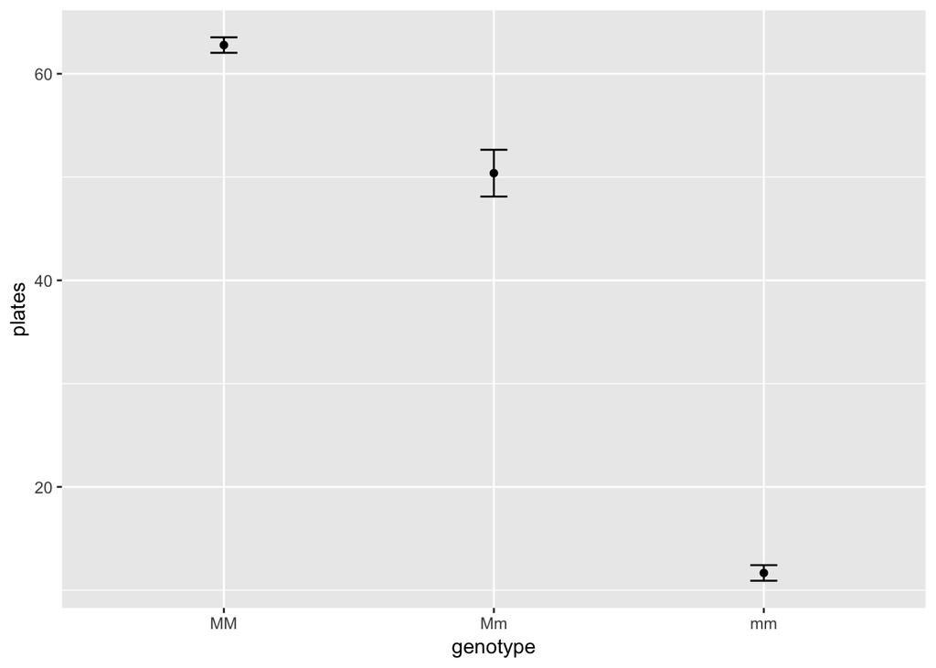

```r
ggplot(data = CIs, aes(x = genotype,y=plates)) +
  geom_point() +
  geom_errorbar(mapping = aes(ymin=plates-ci, ymax=plates+ci), width=.1)
```

*Note:* The function *t.test()* can also be used to calcualte confidence intervalls assuming a normal distribution.

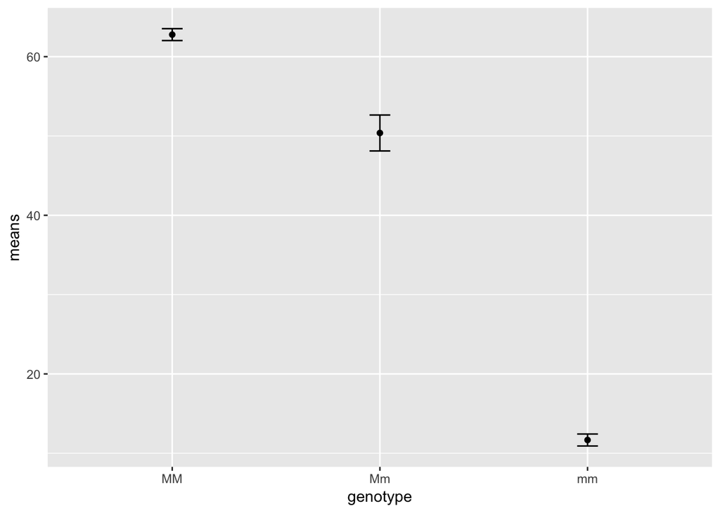

```r
genotpyes = c("MM","Mm","mm")
CI.upper = vector("numeric",3)
CI.lower = vector("numeric",3)
means = vector("numeric",3)

i = 1

for(g in genotypes)
{

  results = t.test(stickleback$plates[stickleback$genotype == g])

  CI.lower[i] = results$conf.int[1]
  CI.upper[i]= results$conf.int[2]
  means[i] = results$estimate
  i = i + 1
}

CI.data = data.frame(genotype = genotpyes,mean = means,CI.lower = CI.lower,CI.upper = CI.upper)

ggplot(data = CI.data, aes(x = genotype,y=means)) +
  geom_point() +
  geom_errorbar(mapping = aes(ymin=CI.lower, ymax=CI.upper), width=.1)
```

# Hypothesis Tests

In this chpater we will learn how to do hypotehsis tests in R. This is very simple, as you will see - often a single line of code is sufficient for conducting a test.

## Binomial-test

We use the binomial test to test whether spermatogenesis genes in the mouse genome occur with unusual frequency on the X chromosome. First, we load the dat set and inspect it:

```r
mouseGenes <- read_csv("~/Dropbox/Teaching/StatisticsForBiology/chap07e2SexAndX.csv")

head(mouseGenes)
```

```
## # A tibble: 6 x 2
##   chromosome onX
##   <chr>      <chr>
## 1 4          no
## 2 4          no
## 3 6          no
## 4 6          no
## 5 6          no
## 6 7          no
```

```r
# Tabulate the number of spermatogenesis genes on the
# X-chromosome and the number not on the X-chromosome.

table(mouseGenes$onX)
```

```
##
##  no yes
##  15  10
```

```r
# Calculate the binomial probabilities of all possible outcomes
# under the null hypothesis. Under the binomial
# distribution with n = 25 and p = 0.061, the number of successes
# can be any integer between 0 and 25.

xsuccesses <- 0:25
probx <- dbinom(xsuccesses, size = 25, prob = 0.061)
data.frame(xsuccesses, probx)
```

```
##    xsuccesses        probx
## 1           0 2.073193e-01
## 2           1 3.367007e-01
## 3           2 2.624760e-01
## 4           3 1.307255e-01
## 5           4 4.670757e-02
## 6           5 1.274386e-02
## 7           6 2.759585e-03
## 8           7 4.865905e-04
## 9           8 7.112305e-05
## 10          9 8.727323e-06
## 11         10 9.071211e-07
## 12         11 8.035781e-08
## 13         12 6.090306e-09
## 14         13 3.956429e-10
## 15         14 2.203032e-11
## 16         15 1.049510e-12
## 17         16 4.261188e-14
## 18         17 1.465509e-15
## 19         18 4.231266e-17
## 20         19 1.012696e-18
## 21         20 1.973624e-20
## 22         21 3.052667e-22
## 23         22 3.605629e-24
## 24         23 3.055193e-26
## 25         24 1.653947e-28
## 26         25 4.297797e-31
```

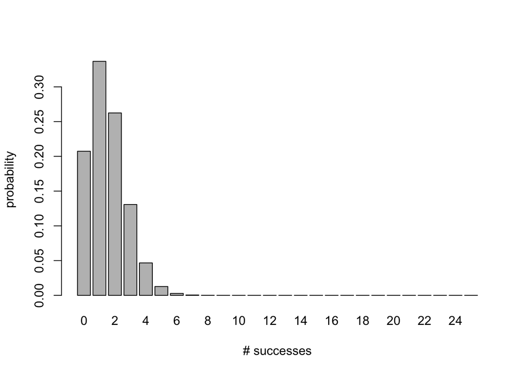

```r
barplot(probx,names.arg=xsuccesses,xlab="# successes",ylab="probability")
```

```r
# Use these probabilities to calculate the P-value corresponding to
# an observed 10 spermatogenesis genes on the X chromosome.
# Remember to multiply the probability of 10 or more successes
# by 2 for the two-tailed test result.

2 * sum(probx[xsuccesses >= 10])
```

```
## [1] 1.987976e-06
```

```r
# For a faster result, try R's built-in binomial test.
# The resulting P-value is slightly different from our calculation. # The output of binom.test includes a confidence interval for the
# proportion using the Clopper-Pearson method, which is more
# conservative than the Agresti-Coull method.

binom.test(10, n = 25, p = 0.061)
```

```
##
##  Exact binomial test
##
## data:  10 and 25
## number of successes = 10, number of trials = 25, p-value =
## 9.94e-07
## alternative hypothesis: true probability of success is not equal to 0.061
## 95 percent confidence interval:
##  0.2112548 0.6133465
## sample estimates:
## probability of success
##                    0.4
```

```r
# Agresti-Coull 95% confidence interval for the proportion
# using the binom package.

library(binom)
binom.confint(30, n = 87, method = "ac")
```

```
##          method  x  n      mean     lower     upper
## 1 agresti-coull 30 87 0.3448276 0.2532164 0.4495625
```

## Chi-square test

Generate the frequency table for the number of time blocks in each number-of-extinctions category. Notice that a simple table does what’s needed, but some extinction categories are not represented (e.g., 0, 12 and 13 extinctions).

```r
extinctTable <- table(extinctData$numberOfExtinctions)
data.frame(Frequency = addmargins(extinctTable))
```

```
##    Frequency.Var1 Frequency.Freq
## 1               1             13
## 2               2             15
## 3               3             16
## 4               4              7
## 5               5             10
## 6               6              4
## 7               7              2
## 8               8              1
## 9               9              2
## 10             10              1
## 11             11              1
## 12             14              1
## 13             16              2
## 14             20              1
## 15            Sum             76
```

To remedy the problem of missing categories, save the original variable as a factor that has all counts between 0 and 20 as levels (note that 20 is not the maximum possible number of extinctions, but it is a convenient cutoff for this table).

```r
extinctData$nExtinctFactor = factor(extinctData$numberOfExtinctions, levels = c(0:20))
extinctTable2 <- table(extinctData$nExtinctFactor)
data.frame(Frequency = addmargins(extinctTable2))
```

```
##    Frequency.Var1 Frequency.Freq
## 1               0              0
## 2               1             13
## 3               2             15
## 4               3             16
## 5               4              7
## 6               5             10
## 7               6              4
## 8               7              2
## 9               8              1
## 10              9              2
## 11             10              1
## 12             11              1
## 13             12              0
## 14             13              0
## 15             14              1
## 16             15              0
## 17             16              2
## 18             17              0
## 19             18              0
## 20             19              0
## 21             20              1
## 22            Sum             76
```

Estimate the mean number of extinctions per time block from the data. The estimate is needed for the goodness-of-fit test.

```r
meanExtinctions <- mean(extinctData$numberOfExtinctions)
meanExtinctions
```

```
## [1] 4.210526
```

Calculate expected frequencies under the Poisson distribution using the estimated mean. (For now, continue to use 20 extinctions as the cutoff, but don’t forget that the Poisson distribution includes the number-of-extinctions categories 21, 22, 23, and so on.)

```r
expectedProportion <- dpois(0:20, lambda = meanExtinctions)
expectedFrequency <- expectedProportion * 76
```

Show the frequency distribution in a histogram.

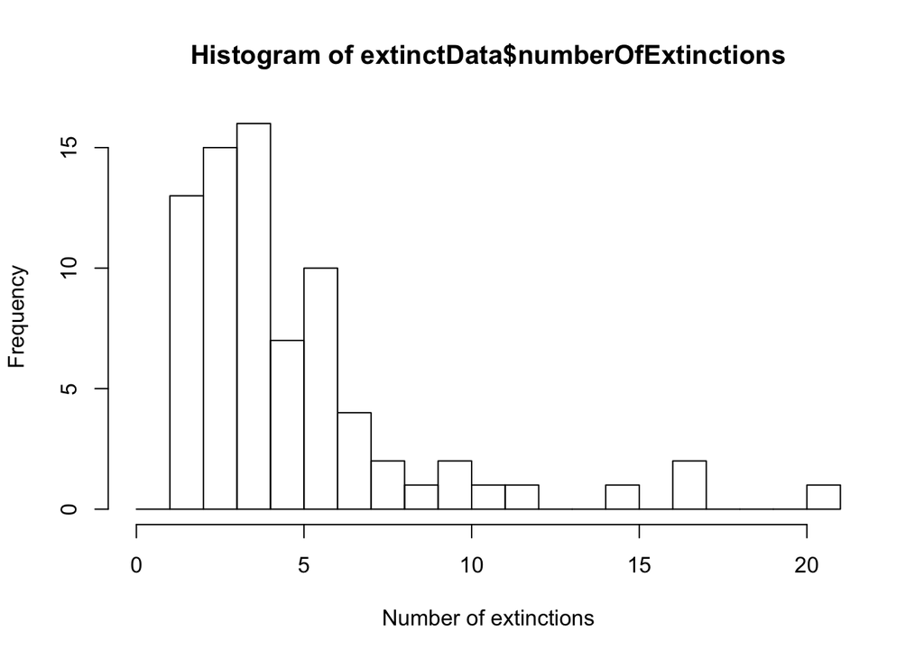

```r
hist(extinctData$numberOfExtinctions, right = FALSE, breaks = seq(0, 21, 1),
    xlab = "Number of extinctions")
```

Make a table of observed and expected frequencies, saving as a data frame.

```r
extinctFreq <- data.frame(nExtinct = 0:20, obsFreq = as.vector(extinctTable2),
    expFreq = expectedFrequency)
extinctFreq
```

```
##    nExtinct obsFreq      expFreq
## 1         0       0 1.127730e+00
## 2         1      13 4.748338e+00
## 3         2      15 9.996501e+00
## 4         3      16 1.403018e+01
## 5         4       7 1.476861e+01
## 6         5      10 1.243672e+01
## 7         6       4 8.727524e+00
## 8         7       2 5.249639e+00
## 9         8       1 2.762968e+00
## 10        9       2 1.292616e+00
## 11       10       1 5.442596e-01
## 12       11       1 2.083290e-01
## 13       12       0 7.309790e-02
## 14       13       0 2.367543e-02
## 15       14       1 7.120431e-03
## 16       15       0 1.998718e-03
## 17       16       2 5.259783e-04
## 18       17       0 1.302733e-04
## 19       18       0 3.047328e-05
## 20       19       0 6.753081e-06
## 21       20       1 1.421701e-06
```

The low expected frequencies will violate the assumptions of the χ2 test, so we will need to group categories. Create a new variable that groups the extinctions into fewer categories.

```r
extinctFreq$groups <- cut(extinctFreq$nExtinct,
    breaks = c(0, 2:8, 21), right = FALSE,
    labels = c("0 or 1","2","3","4","5","6","7","8 or more"))
extinctFreq
```

```
##    nExtinct obsFreq      expFreq    groups
## 1         0       0 1.127730e+00    0 or 1
## 2         1      13 4.748338e+00    0 or 1
## 3         2      15 9.996501e+00         2
## 4         3      16 1.403018e+01         3
## 5         4       7 1.476861e+01         4
## 6         5      10 1.243672e+01         5
## 7         6       4 8.727524e+00         6
## 8         7       2 5.249639e+00         7
## 9         8       1 2.762968e+00 8 or more
## 10        9       2 1.292616e+00 8 or more
## 11       10       1 5.442596e-01 8 or more
## 12       11       1 2.083290e-01 8 or more
## 13       12       0 7.309790e-02 8 or more
## 14       13       0 2.367543e-02 8 or more
## 15       14       1 7.120431e-03 8 or more
## 16       15       0 1.998718e-03 8 or more
## 17       16       2 5.259783e-04 8 or more
## 18       17       0 1.302733e-04 8 or more
## 19       18       0 3.047328e-05 8 or more
## 20       19       0 6.753081e-06 8 or more
## 21       20       1 1.421701e-06 8 or more
```

Then sum up the observed and expected frequencies within the new categories.

```r
obsFreqGroup <- tapply(extinctFreq$obsFreq, extinctFreq$groups, sum)
expFreqGroup <- tapply(extinctFreq$expFreq, extinctFreq$groups, sum)
data.frame(obs = obsFreqGroup, exp = expFreqGroup)
```

```
##           obs       exp
## 0 or 1     13  5.876068
## 2          15  9.996501
## 3          16 14.030177
## 4           7 14.768608
## 5          10 12.436722
## 6           4  8.727524
## 7           2  5.249639
## 8 or more   9  4.914760
```

The expected frequency for the last category, “8 or more”, doesn’t yet include the expected frequencies for the categories 21, 22, 23, and so on. However, the expected frequencies must sum to 76. In the following, we recalculate the expected frequency for the last group, expFreqGroup[length(expFreqGroup)], as 76 minus the sum of the expected frequencies for all the other groups.

```r
expFreqGroup[length(expFreqGroup)] = 76 - sum(expFreqGroup[1:(length(expFreqGroup)-1)])
data.frame(obs = obsFreqGroup, exp = expFreqGroup)
```

```
##           obs       exp
## 0 or 1     13  5.876068
## 2          15  9.996501
## 3          16 14.030177
## 4           7 14.768608
## 5          10 12.436722
## 6           4  8.727524
## 7           2  5.249639
## 8 or more   9  4.914761
```

Finally, we are ready to carry out the χ2 goodness-of-fit test. R gives us a warning here because one of the expected frequencies is less than 5. However, we have been careful to meet the assumptions of the χ2 test, so let’s persevere. Once again, R doesn’t know that we’ve estimated a parameter from the data (the mean), so it won’t use the correct degrees of freedom when calculating the P-value. As before, we need to grab the χ2 value calculated by chisq.test and recalculate P using the correct degrees of freedom. Since the number of categories is now 8, the correct degrees of freedom is 8 - 1 - 1 = 6.

```r
saveChiTest <- chisq.test(obsFreqGroup, p = expFreqGroup/76)
```

```
## Warning in chisq.test(obsFreqGroup, p = expFreqGroup/76): Chi-squared
## approximation may be incorrect
```

```r
saveChiTest # Wrong degrees of freedom, so wrong P-value!
```

```
##
##  Chi-squared test for given probabilities
##
## data:  obsFreqGroup
## X-squared = 23.95, df = 7, p-value = 0.001163
```

```r
pValue <- 1 - pchisq(saveChiTest$statistic, df = 6)
unname(pValue) # correct P-value!
```

```
## [1] 0.0005334919
```

## t-test

### One-sample t-test

We use a one-sample t-test to compare body temperature in a random sample of people with the “expected” temperature 98.6 °F.

Read and inspect the data:

```r
heat <- read.csv(url("http://www.zoology.ubc.ca/~schluter/WhitlockSchluter/wp-content/data/chapter11/chap11e3Temperature.csv"))
head(heat)
```

```
##   individual temperature
## 1          1        98.4
## 2          2        98.6
## 3          3        97.8
## 4          4        98.8
## 5          5        97.9
## 6          6        99.0
```

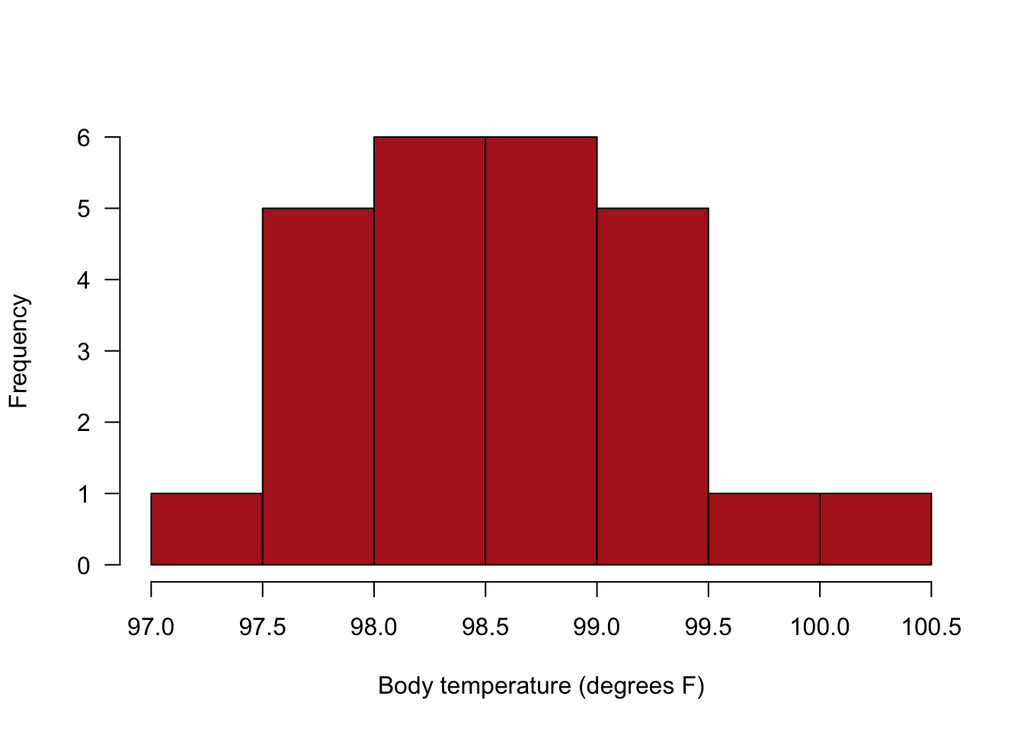

```r
hist(heat$temperature, right = FALSE, breaks = seq(97, 100.5, by = 0.5),
    col = "firebrick", las = 1, xlab = "Body temperature (degrees F)",
    ylab = "Frequency", main = "")
```

One-sample t-test can be calculate using the fucntion t.test. The mu argument gives the value stated in the null hypothesis.

```r
t.test(heat$temperature, mu = 98.6)
```

```
##
##  One Sample t-test
##
## data:  heat$temperature
## t = -0.56065, df = 24, p-value = 0.5802
## alternative hypothesis: true mean is not equal to 98.6
## 95 percent confidence interval:
##  98.24422 98.80378
## sample estimates:
## mean of x
##    98.524
```

### Two-sample t-test

WE calcaulte a confidence interval for the difference between two means, and the two-sample t-test, comparing horn length of live and dead (spiked) horned lizards.

```r
lizard <- read.csv(url("http://www.zoology.ubc.ca/~schluter/WhitlockSchluter/wp-content/data/chapter12/chap12e3HornedLizards.csv"))
head(lizard)
```

```
##   squamosalHornLength Survival
## 1                25.2   living
## 2                26.9   living
## 3                26.6   living
## 4                25.6   living
## 5                25.7   living
## 6                25.9   living
```

Note that there is one missing value for the variable “squamosalHornLength”. Everything is easier if we eliminate the row with missing data.

```r
lizard2 <- na.omit(lizard)
head(lizard2)
```

```
##   squamosalHornLength Survival
## 1                25.2   living
## 2                26.9   living
## 3                26.6   living
## 4                25.6   living
## 5                25.7   living
## 6                25.9   living
```

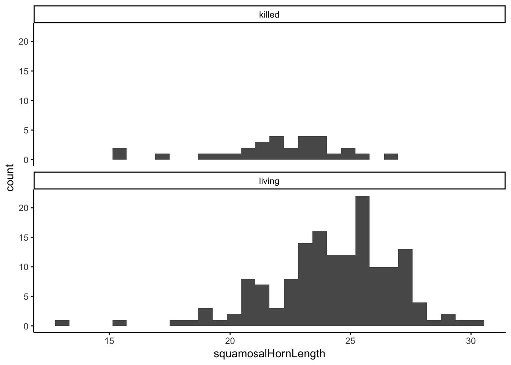

```r
ggplot(data = lizard2) +
  geom_histogram(mapping = aes(x = squamosalHornLength )) +
  facet_wrap( ~Survival,nrow=2) +
  theme_classic()
```

A two-sample t-test of the difference between two means can be carried out with t.test by using a formula, asking if squamosalHornLength is predicted by Survival, and specifying that the variables are in the data frame lizard.

```r
t.test(squamosalHornLength ~ Survival, data = lizard)
```

```
##
##  Welch Two Sample t-test
##
## data:  squamosalHornLength by Survival
## t = -4.2634, df = 40.372, p-value = 0.0001178
## alternative hypothesis: true difference in means is not equal to 0
## 95 percent confidence interval:
##  -3.381912 -1.207092
## sample estimates:
## mean in group killed mean in group living
##             21.98667             24.28117
```

The same reuslt could be achieved with

```r
t.test(lizard$squamosalHornLength[lizard$Survival=="killed"], lizard$squamosalHornLength[lizard$Survival=="living"])
```

```
##
##  Welch Two Sample t-test
##
## data:  lizard$squamosalHornLength[lizard$Survival == "killed"] and lizard$squamosalHornLength[lizard$Survival == "living"]
## t = -4.2634, df = 40.372, p-value = 0.0001178
## alternative hypothesis: true difference in means is not equal to 0
## 95 percent confidence interval:
##  -3.381912 -1.207092
## sample estimates:
## mean of x mean of y
##  21.98667  24.28117
```

```r
t.test(squamosalHornLength ~ Survival, data = lizard)$conf.int
```

```
## [1] -3.381912 -1.207092
## attr(,"conf.level")
## [1] 0.95
```

*Note: R has used the Welch two sample t-test here. If we want to force R to use the standrad t.test we set a parameter specifiying this:

```r
t.test(squamosalHornLength ~ Survival, data = lizard,var.equal = TRUE)
```

```
##
##  Two Sample t-test
##
## data:  squamosalHornLength by Survival
## t = -4.3494, df = 182, p-value = 2.27e-05
## alternative hypothesis: true difference in means is not equal to 0
## 95 percent confidence interval:
##  -3.335402 -1.253602
## sample estimates:
## mean in group killed mean in group living
##             21.98667             24.28117
```

# Deviations from Normailty

## QQ Plots and Transformations

We investigate the ratio of biomass between marine reserves and non-reserve control areas.

```r
marine <- read.csv(url("http://www.zoology.ubc.ca/~schluter/WhitlockSchluter/wp-content/data/chapter13/chap13e1MarineReserve.csv"))
head(marine)
```

```
##   biomassRatio
## 1         1.34
## 2         1.96
## 3         2.49
## 4         1.27
## 5         1.19
## 6         1.15
```

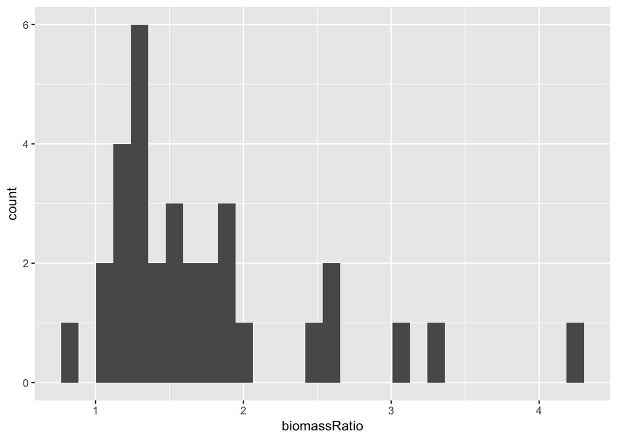

```r
ggplot(data = marine) +
  geom_histogram(mapping = aes(x = biomassRatio))
```

Normal quantile plot of biomass ratio data.

```r
library(car)
```

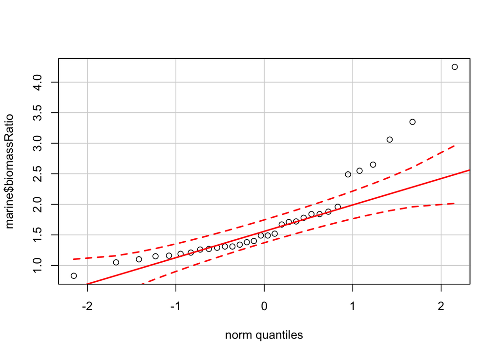

```r
qqPlot(marine$biomassRatio, distribution = "norm")
```

The function log() takes the natural logarithm of all the elements of a vector or variable. The following command puts the results into a new variable in the same data frame, marine.

```r
marine = mutate(marine,logBiomassRatio =  log(biomassRatio))
```

Histogram and QQ-Plot of the log-transformed marine biomass ratio.

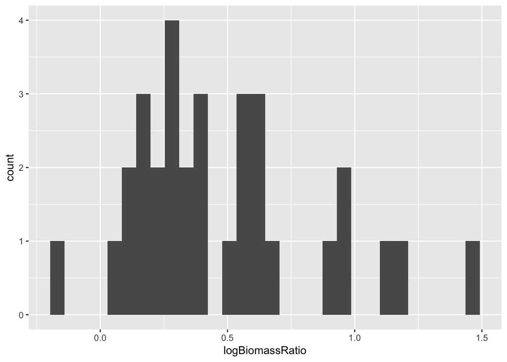

```r
ggplot(data = marine) +
  geom_histogram(mapping = aes(x = logBiomassRatio))
```

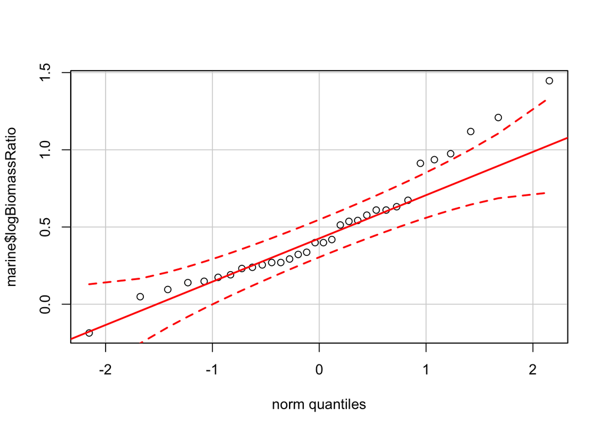

```r
qqPlot(marine$logBiomassRatio, distribution = "norm")
```

95% confidence interval of the mean using the log-transformed data.

```r
t.test(marine$logBiomassRatio)$conf.int
```

```
## [1] 0.3470180 0.6112365
## attr(,"conf.level")
## [1] 0.95
```

Back-transform lower and upper limits of confidence interval (exp is the inverse of the log function).

```r
exp(t.test(marine$logBiomassRatio)$conf.int )
```

```
## [1] 1.414842 1.842708
## attr(,"conf.level")
## [1] 0.95
```